# Milestone Report

PF

4 8 2017

## Capstone Project

The goal of the capstone project is to understand and build predictive text models. Moreover, a data product needs to be built to make the predictive text model available.

## Helpful Packages

Working with text files and predicting words require specific R packages. The ANLP package helps to sample and clean text data, build N-gram models, backoff algorithms etc. It depends on tm, gdap, RWeka and dplyr packages. I will use the ANLP package to perform the analysis.

## Data

The data can be downloaded from https://d396qusza40orc.cloudfront.net/dsscapstone/dataset/Coursera-SwiftKey.zip.

The data set contains 12 text files in four languages (German, English, Finnish and Russian) from three sources (blogs, news, twitter). I will work with the English texts.

### Loading the Data

```r
library(tm)
library(rJava)
library(RWeka)
library(qdap)
library(ANLP)
```

```r
blogsEN <- readTextFile("final/en_US/en_US.blogs.txt", "UTF-8")
newsEN <- readTextFile("final/en_US/en_US.news.txt", "UFT-8")
twitterEN <- readTextFile("final/en_US/en_US.twitter.txt", "UFT-8")
```

Loading the files shows that they are huge:

| File | Number of Elements | Size |
| --- | --- | --- |
| blogsEN | 899288 | 248.5 Mb |
| newsEN | 1010242 | 249.6 Mb |
| twitterEN | 2360148 | 301.4 Mb |

### Sampling the Data

For better handling, I sample a random 5% of each of the three text files for further exploration.

```r
set.seed(3461)
blogsEN <- sampleTextData(blogsEN, 0.05)
newsEN <- sampleTextData(newsEN, 0.05)
twitterEN <- sampleTextData(twitterEN, 0.05)

write.csv(blogsEN, file = "final/en_US/random_sample/blogsEN", row.names = FALSE)
write.csv(newsEN, file = "final/en_US/random_sample/newsEN", row.names = FALSE)
write.csv(twitterEN, file = "final/en_US/random_sample/twitterEN", row.names = FALSE)
```

### Creating a Corpus

To be able to work and compute on texts with statistial techniques and data mining, I transform the texts into a structured format, the so-called term-document matrix or corpus (Source: Feinerer et al. (2008), Text Mining Infrastructure in R, Journal of Statistical Software, Vol 25, Issue 5).

```r
data <- VCorpus(DirSource("final/en_US/random_sample"),
                readerControl = list(reader = readPlain, language = "en_US"))
```

### Cleaning the Data

The function *clearTextData* removes non-English characters, numbers, white spaces, brackets and punctuation. It converts all the words to lower case and replaces abbreviations as well as contractions with long form.

```r
cleanTextData(data)
```

```
## <<SimpleCorpus>>
## Metadata:  corpus specific: 1, document level (indexed): 0
## Content:  documents: 1
```

As required I also remove profanity. I use the bad words list of Google to get rid of the profane words. The list contains 550 words and can be downloaded from https://www.freewebheaders.com/full-list-of-bad-words-banned-by-google/.

```r
badwords <- VectorSource(readLines("bad_words.txt"))
data <- tm_map(data, removeWords, badwords)
```

## Exploratory Analysis

To get an idea of the words’ frequencies in the data, I create a word cloud.

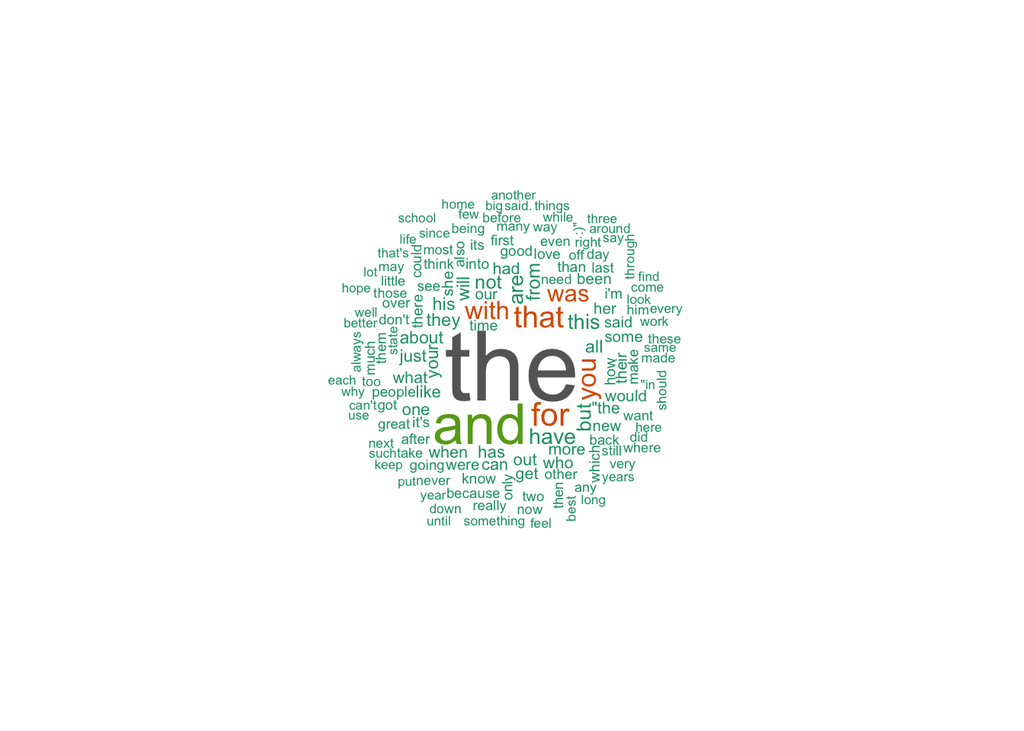

```r
library(wordcloud)
wordcloud(data, max.words = 150, random.order = FALSE, colors = brewer.pal(8, "Dark2"))
```

The histograms below show the most frequent (top 20) distinct words, bigrams and trigrams:

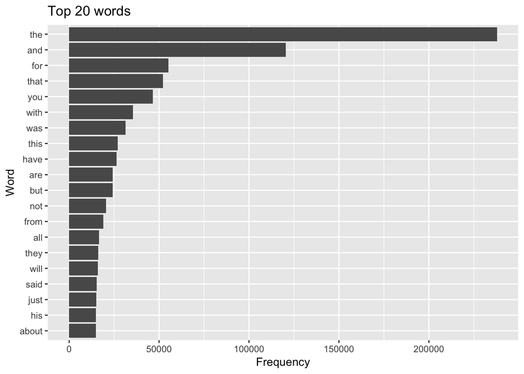

```r
library(ggplot2)
library(grid)
library(gridExtra)
unigram <- generateTDM(data, N = 1, isTrace = FALSE)
unigramTop20 <- unigram[1:20,]
p1 <- ggplot(data = unigramTop20, aes(x=reorder(word, freq), y=freq)) + geom_bar(stat="identity") +
        ggtitle("Top 20 words") + ylab("Frequency") + xlab("Word") + coord_flip()
p1
```

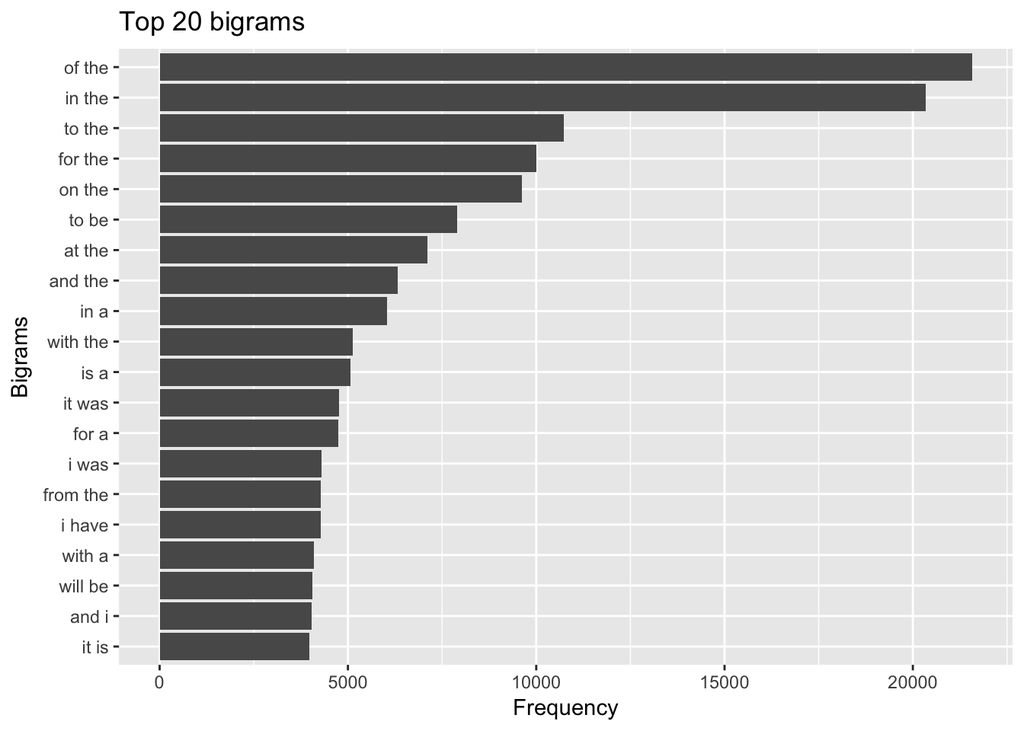

```r
bigram <- generateTDM(data, N = 2, isTrace = FALSE)
bigramTop20 <- bigram[1:20,]
p2 <- ggplot(data = bigramTop20, aes(x=reorder(word, freq), y=freq)) + geom_bar(stat="identity") +
        ggtitle("Top 20 bigrams") + ylab("Frequency") +xlab("Bigrams") + coord_flip()
p2
```

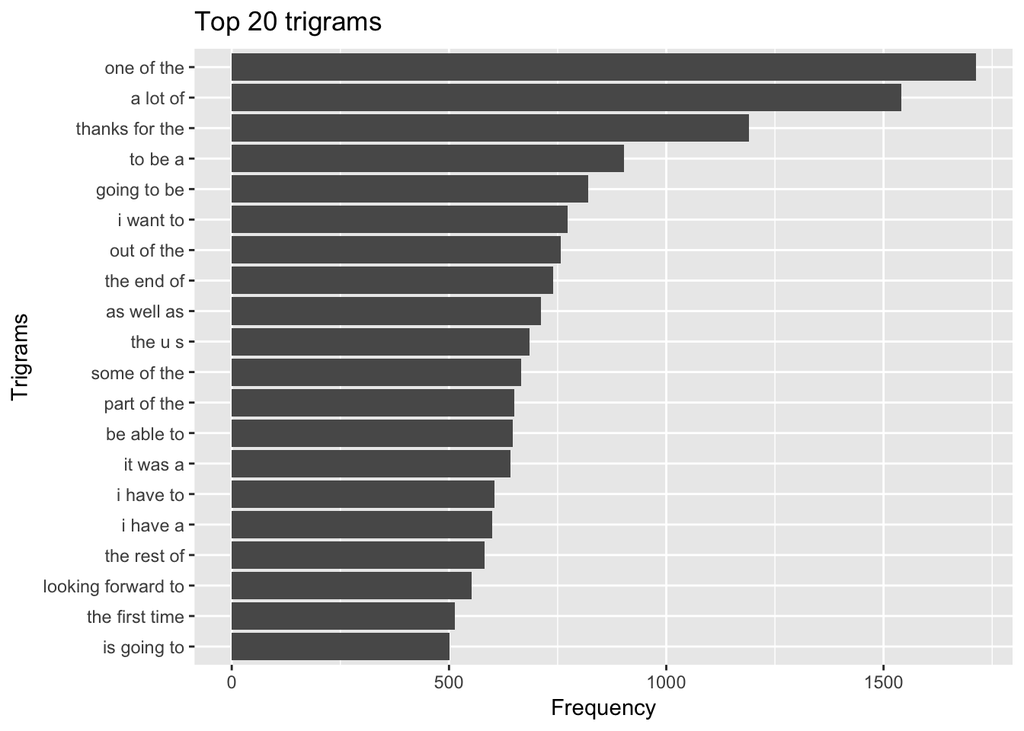

```r
trigram <- generateTDM(data, N = 3, isTrace = FALSE)
trigramTop20 <- trigram[1:20,]
p3 <- ggplot(data = trigramTop20, aes(x=reorder(word, freq), y=freq)) + geom_bar(stat="identity") +
        ggtitle("Top 20 trigrams") + ylab("Frequency") + xlab("Trigrams") + coord_flip()
p3
```

I also compute the number of unique words needed to cover 50% and 90% of the data.

```r
coverage_unique <- function(x,y){
        nwords <- 0
        coverage <- y*sum(x$freq)
        for(i in 1:nrow(x)){
                if(nwords >= coverage){return(i)}
                nwords <- nwords +x$freq[i]
        }
}
coverage_unique(unigram,0.5)
```

```
## [1] 348
```

```r
coverage_unique(unigram, 0.9)
```

```
## [1] 12356
```

348 words are needed to cover 50% of the data and 12356 words are needed to cover 90% of the data. These numbers seem to be quite small. One reason for the small numbers is that I did not exlude stop words. These are the most common words in a language. If I excluded these stop words, the number of words needed for a certain coverage would certainly increase. However, the exclusion of stop words in a word prediction excercise does not make sense.

## Prediction Model

To predict the next word, I plan to use a back-off model (e.g., Katz’s back-off model). Such a model takes the input and splits it into single words. Then it takes the input’s longest ngram and tests with the corresponding n-gram model whether it can predict the next word. If the longest ngram cannot be found in the data, it takes the shorter ngram, does exactly the same and so on until it gets a prediction.